# Catalase_SOD

Sander Wuyts

May 16, 2017

# Introduction

Lactobacillus casei N87 is hypothized to be respiration-competent as well as resistant to oxidative stress. Tolerance of oxygen and oxidative stresses may be important in the survival in different environments, including the gut, and during preservation of starter.

The suprising thing is the fact that N87 (GCA_001013375) clusters directly next to AMBR2, in Clade B. So our research question is:

> Do all genomes present in Clade B show tolerance to oxygen and oxidative stress?

# Catalase

## Annotation approach

The dataobject used in the GC analysis contains all the annotated genes of all our studied genomes. This is a very useful starting place for this analysis.

Let’s search for catalase in the annotation

```
## [1] 19
```

```
##  [1] "AMBR2"         "GCA_000260435" "GCA_000414365" "GCA_000615205"
##  [5] "GCA_000814185" "GCA_000829055" "GCA_001013375" "GCA_001066695"
##  [9] "GCA_001433745" "GCA_001812525" "GCA_001940585"
```

```
##               Genome  Clade
## 585            AMBR2 cladeB
## 643            AMBR2 cladeB
## 44577  GCA_000260435 cladeB
## 44673  GCA_000260435 cladeB
## 159056 GCA_000414365 cladeC
## 159057 GCA_000414365 cladeC
## 187127 GCA_000615205 cladeB
## 222910 GCA_000814185 cladeB
## 231943 GCA_000829055 cladeB
## 247331 GCA_001013375 cladeB
## 247387 GCA_001013375 cladeB
## 282347 GCA_001066695 cladeB
## 283479 GCA_001066695 cladeB
## 330408 GCA_001433745 cladeB
## 331748 GCA_001433745 cladeB
## 464249 GCA_001812525 cladeB
## 464306 GCA_001812525 cladeB
## 504628 GCA_001940585 cladeB
## 504661 GCA_001940585 cladeB
```

We found 19 hits in 11 genomes, all belonging to clade B except for 1.

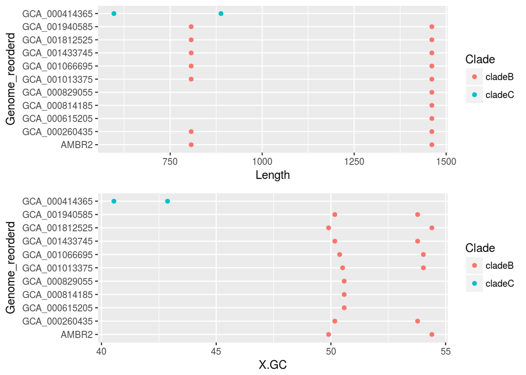

Interestingly, we found catalase genes in all 10 clade B’s. Moreover in 7/10 we found at least catalase genes!

## Blast approach

In Zotta et al 2014 they give a good overview of studied catalase genes in lactobacillus strains. I’ve found 2 of these genes in the gene database of NCBI (https://www.ncbi.nlm.nih.gov/gene/?term=catalase+lactobacillus) + 1 extra:

- L. plantarum WCFS1 heme dependent catalase (https://www.ncbi.nlm.nih.gov/gene/1062016)
- L. sakei heme dependent catalase (https://www.ncbi.nlm.nih.gov/gene/29637976)
- Lactobacillus brevis ATCC 367 catalase (https://www.ncbi.nlm.nih.gov/gene/4413348)

All of these sequences were put together in a file called “Described_catalases.fasta”

Important note. It is claimed that there is a pseudocatalase which is Manganese dependent isolated from L. plantarum ATCC 14431. HOWEVEVER it was very hard to find the sequence of this one (a lot of old papers are cited here). After long digging I’ve found the sequence using the following approach:

- Review paper: Diversity of structures and properties among catalases
- PDB with number 1JKU at http://www.rcsb.org/pdb/home/home.do
- http://www.rcsb.org/pdb/explore/remediatedSequence.do?structureId=1JKU
- Downloaded protein FASTA sequence

To add this sequence to the analysis, I’ve skipped the first step of blastaiganstroary.sh and translated the “Described_catalases.fasta” first then added the protein sequence in a file called described_catalases_all.faa and used that as an input for balstaiganstorthinder.sh.

This resulted in the following top hits per gene:

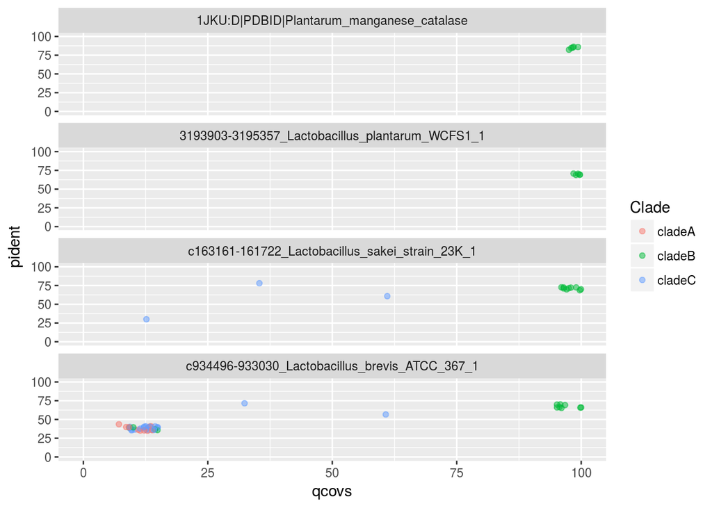

Warning, there is some pretty high jitter on the above graph (3% in every direction) to improve visualisation.

This approach confirms our annotation approach:

- 7/10 clade B hits for the manganese catalase
- 10/10 clade B hits for all other catalases
- 1 clade C hit, that seems to be fragmented

### PFAM HMMs

As a last de novo approach we’ll be using the HMM of PFAM. We’ll use two, the catalase one and the manganese depndent-catalase:

- http://pfam.xfam.org/family/Catalase#tabview=tab6
- http://pfam.xfam.org/family/PF05067#tabview=tab6

Then ran hmmscan in the script ‘scan_catalase_hmms_against_orthofinder.sh’ and now we can read in the output here:

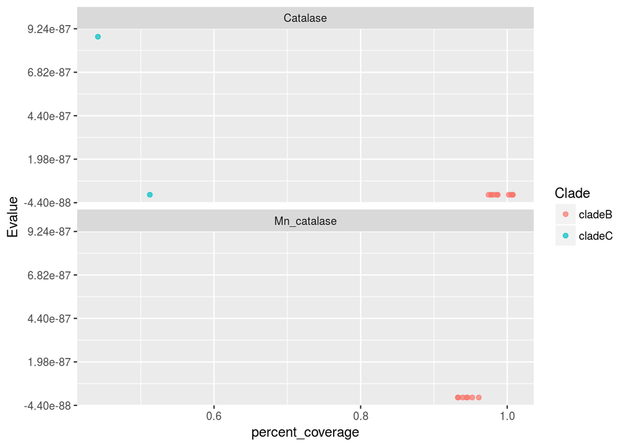

These results, again confirm our findings.

## Conclusion

- 7/10 clade B hits for the manganese catalase
- 10/10 clade B hits for heme catalases
- 1 clade C hit, that seems to be fragmented

# SOD

Super oxide dismutase is another very important enzyme in scavenging O2 radicals. It is not found in lactobacillus in general.

## Annotation approach

```
## [1] 69
```

```
##  [1] "GCA_000014525" "GCA_000019245" "GCA_000026485" "GCA_000155515"
##  [5] "GCA_000194765" "GCA_000194785" "GCA_000309565" "GCA_000309585"
##  [9] "GCA_000309605" "GCA_000309625" "GCA_000309645" "GCA_000309665"
## [13] "GCA_000309685" "GCA_000309705" "GCA_000309725" "GCA_000309745"
## [17] "GCA_000309765" "GCA_000309785" "GCA_000318035" "GCA_000376145"
## [21] "GCA_000388095" "GCA_000400585" "GCA_000409835" "GCA_000409855"
## [25] "GCA_000409875" "GCA_000409895" "GCA_000409935" "GCA_000409955"
## [29] "GCA_000409995" "GCA_000410015" "GCA_000410035" "GCA_000410135"
## [33] "GCA_000410155" "GCA_000410175" "GCA_000410195" "GCA_000410235"
## [37] "GCA_000410335" "GCA_000410415" "GCA_000410455" "GCA_000410475"
## [41] "GCA_000418515" "GCA_000474615" "GCA_000508845" "GCA_000510825"
## [45] "GCA_000582665" "GCA_000829035" "GCA_000949485" "GCA_000958505"
## [49] "GCA_000958525" "GCA_001062665" "GCA_001062695" "GCA_001066565"
## [53] "GCA_001076595" "GCA_001076935" "GCA_001191565" "GCA_001244395"
## [57] "GCA_001433735" "GCA_001436385" "GCA_001469115" "GCA_001514415"
## [61] "GCA_001540885" "GCA_001636215" "GCA_001816065" "GCA_001858275"
## [65] "GCA_001885295" "GCA_001895185" "GCA_001981715" "GCA_001982085"
## [69] "GCA_001982095"
```

```
##               Genome  Clade
## 7451   GCA_000014525 cladeA
## 10258  GCA_000019245 cladeA
## 13332  GCA_000026485 cladeA
## 22068  GCA_000155515 cladeA
## 27945  GCA_000194765 cladeA
## 31032  GCA_000194785 cladeA
## 47970  GCA_000309565 cladeA
## 50802  GCA_000309585 cladeA
## 52644  GCA_000309605 cladeA
## 57396  GCA_000309625 cladeA
## 60789  GCA_000309645 cladeA
## 64130  GCA_000309665 cladeA
## 67037  GCA_000309685 cladeA
## 70040  GCA_000309705 cladeA
```

[output cut: 55 more lines]

We found 69 hits in 69 genomes, all belonging to clade A.

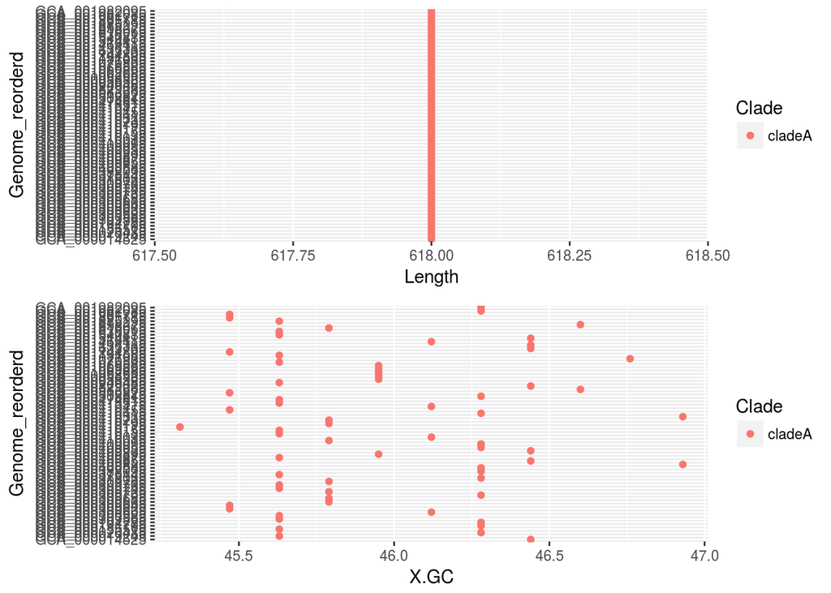

Apparently it’s only found in CladeA.

## Blast Approach

There’s only one good described SOD gene for lactobacillus from lactobacillus casei Lc18 which has been sort of functionally tested by expression in e coli (http://link.springer.com/article/10.1007%2Fs13213-011-0237-2). If you blast that we get this:

```
## [1] 69
```

```
## [1] 69
```

Again, we found 69 hits in 69 genomes, all belonging to cladeA.

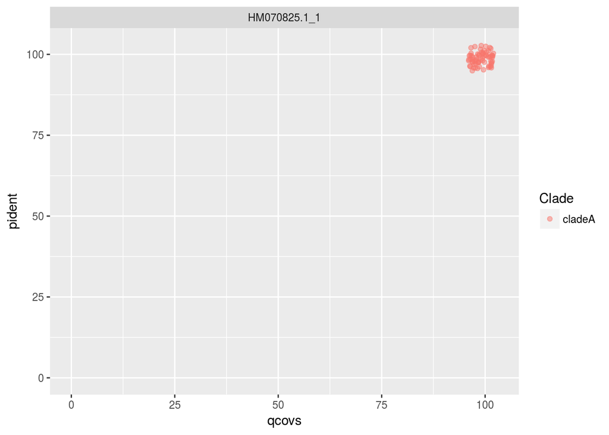

They seem to be pretty good hits!

## Hmm approach

Let’s confirm this extra by downloading some Hmms from PFAM and scan against those with following HMMS:

- http://pfam.xfam.org/family/PF00080
- http://pfam.xfam.org/family/PF00081
- http://pfam.xfam.org/family/PF02777
- http://pfam.xfam.org/family/PF09055

Then ran hmmscan in the script ‘scan_sod_hmms_against_orthofinder.sh’ and now we can read in the output here:

```
## [1] 73
```

```
## [1] 69
```

There are 73 hits in 69 genomes

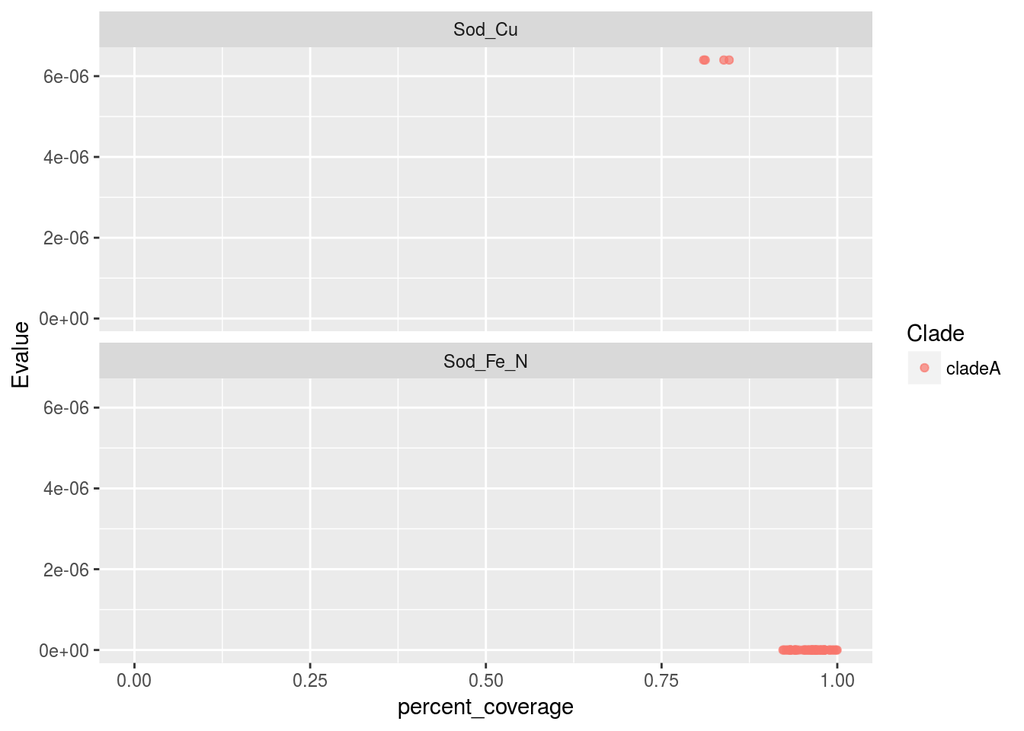

Same results!

## Conclusion

SOD is found only in clade A and in 69 of 70 genomes.